# Tvyal Newsletter

Aghasi Tavadyan

2024-03-29

*English summary below.*

Հարգելի գործընկեր,

Հուսով եմ լավ եք: Ներկայացնում եմ այս շաբաթվա վերլուծությունները և աշխատանքները.

**ՈՒՇԱԴՐՈՒԹՅՈՒՆ․ ՄԵՆՔ !!PODCAST!! ՈՒՆԵՆՔ․ ՄԱՆՐԱՄԱՍՆԵՐԸ ՆԵՐՔԵՎՈՒՄ**

## 🌿🤨💎 Թանկարժեք էֆեկտ․ 2024 թվականի տնտեսական աճի պատճառները

Տնտեսական ակտիվության ցուցանիշը 2024 թվականի փետրվարին կազմել է 16.3%, հիմնականում պայմանավորված հենց փետրվար ամսում գրանցված աճով՝ 11.2%։

**Գծապատկեր 1.**

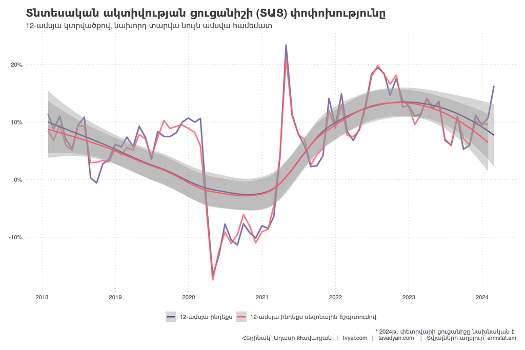

Ինչպես երևում է գծապատկերից, տնտեսական ակտիվության միտումը 2023 թվականի սկզբից բացասական է, որը շարունակվել է մինչև 2024 թվականի փետրվար ամիսը։ Նշենք, որ մեկ ամսում գրանցված կտրուկ աճը չի կարող բավարար հիմք հանդիսանալ այն պնդման համար, որ տնտեսությունը հաղթահարել է տնտեսական աճի դանդաղման միտումը։

2024 թվականի փոտրվարին տնտեսական ակտիվության ցուցանիշը կտրուկ աճել է, որի արդյունքում տարեկան կտրվածքով աճը նախորդ տարվա փտրվարի համեմատ կազմել է 16.3%։ Սակայն այս աճը պայմանավորված է կարճաժամկետ գործոնով՝ հիմնականում ոսկերչական գործունեության կտրուկ աճով։ Այսպես 2024 թվականի Հայաստանի 8.4 մլրդ դոլար արտահանման 21.5 տոկոսը կամ 1.8 մլրդ դոլարը կազմել է ոսկու արտահանումը, իսկ 7.0 տոկոսը կամ 589 միլիոն դոլարը ադամանդների արտահանումը։ [Ըդհանուր առմամբ արտահանման 28.5 տոկոսը եղել է ոսկու և ադամանդնարի վերաարտահանում Ռուսատանից դեպի Արաբական Միացյալ Էմիրություններ և Հոնկոնգ](https://www.tvyal.com/newsletter/2024/2024_02_16)։ Այս կարճաժամկետ միտումները վտանգավոր են, քանի որ աճը ամբողջությամբ հիմնված է արտաքին գործոնի վրա, որը անկանխատեսելի է` արտաքին միջավայրի հանկարծակի փոփոխությամբ պայմանավորված: Նշենք նաև, որ 2023 թվականի վերջին ամիսներին թանկարժեք քարերի և մետաղների վերաարտահանումը ապահովել է 8.7 տոկոս տնտեսական աճի մոտ 1.5-2 տոկոսային կետ հավելաճը։ Առկա է հավանականություն որ այս արտաքին ազդակներով պայմանավորված գործունեությունը կարող է դադարել։ Հայաստանի տնտեսական աճի զգալի մասն ապահովում է առևտրաշրջանառությունը, արտաքին խթանների փոփոխության պայմաններում տնտեսության վիճակը կարող է վատթարանալ։

> Կարդացեք թե որ ճյուղերն են նպաստում տնտեսական աճին․

> [🇦🇲📊🏗️ Հայաստանի 2023թ․ 8.7% տնտեսական աճի հիմնական պատճառները](https://www.tvyal.com/newsletter/2024/2024_03_09)։

Ոսկերչական գործունեության աճը հանգեցրել է արտահանման ծավալների 55 տոկոս աճին։ Թեև այս աճը արտարժույթ է բերում Հայաստանի տնտեսություն, դրա դրական ազդեցությունը որոշակիորեն չեզոքանում է ներմուծման գրեթե համարժեք աճով: Այս արագ աճի պայմաններում առկա արտահանման դասական ճյուղերը կրճատվում են, [նկատվում է ապրանքների տարբեր կատեգորիաների արտահանման կրճատում](https://www.tvyal.com/newsletter/2024/2024_02_16): Մասնավորապես նկատվում է «պատրաստի սննդի արտադրանք» և «կենդանի կենդանիներ և կենդանական ծագման արտադրանք» ապրանքախմբերի արտահանման ծավալների անկում, խնդրահարույց է նաև հանքահումքային ապրանքների արտահանման էական անկումը:

Արդյունաբերության բարձր աճին զուգահեռ, մշակող արդյունաբերության որոշ` ՀՀ տնտեսության համար էական ենթաճյուղեր շարունակում են անկում ապրել: Մասնավորապես, սննդամթերքի, ծխախոտի, հագուստի, քիմիական նյութերի և քիմիական արտադրության ենթաոլորտներում 2024թ. հունվարին անկում է գրանցվել: Ստացվում է, որ մշակող արդյունաբերության համեմատաբար կայուն և երկարաժամկետ գործունեության տեսակները նվազում են, իսկ կարճաժամկետ գործունեությունն էական աճ է գրանցում՝ վատթարացնելով արդյունաբերության կառուցվածքը:

**Գծապատկեր 2.**

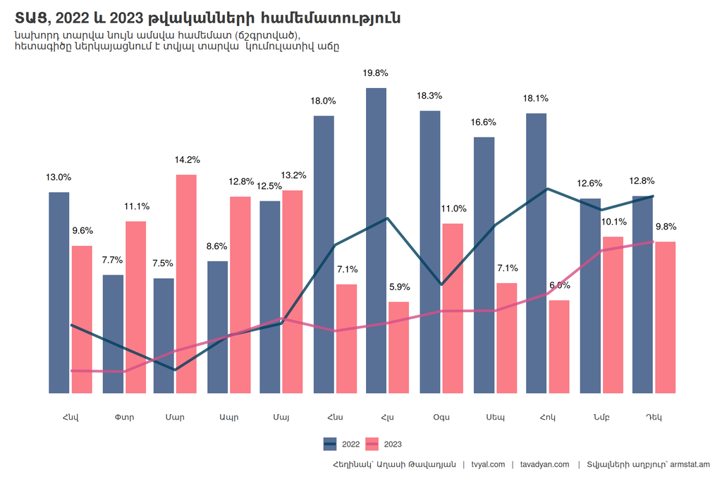

Երրորդ գծապատկերում պատկերված է տնտեսական ակտիվության բաղադրիչները ըստ տարիների։ Նշենք որ գյուղատնտեսությունը ամսական կտրվածքով արտացոլվում էր մինչև 2018 թվականի վերջը վիճակագրության կոմիտեի կողմից ներկայացված [Հայաստանի սոցիալ-տնտեսական վիճակը բնութագրող ընթացիկ-օպերատիվ մակրոտնտեսական ցուցանիշների մեջ](https://armstat.am/file/doc/99511688.pdf)։ [2019 թվականից ի վեր գյուղատնտեսության ամսական տվյալները անտեսվել են](https://armstat.am/file/doc/99517378.pdf): Գյուղատնտեսությունը կազմում էր տնտեսական ակտիվության 12.9 տոկոսը 2017 թվականին, 2023-ին այս ոլորտի մասնաբաժինը արդեն կրճատվեց մինչև 7.4 տոկոս։ Ամենախոշոր ոլորտը տնսական ակտիվության մեջ մեծածախ և մանրածախ առևտուրն է, որի մասնաբաժինը արդեն կազմում է 42.7 տոկոս։

> Ձեզ կարող է հետաքրքրել նաև հետևյալ վերլուծությունը.

> [🚜🌾📉 10 տարվա գյուղատնտեսության կոլափսը](https://www.tvyal.com/newsletter/2024/2024_03_15)։

**Գծապատկեր 3.**

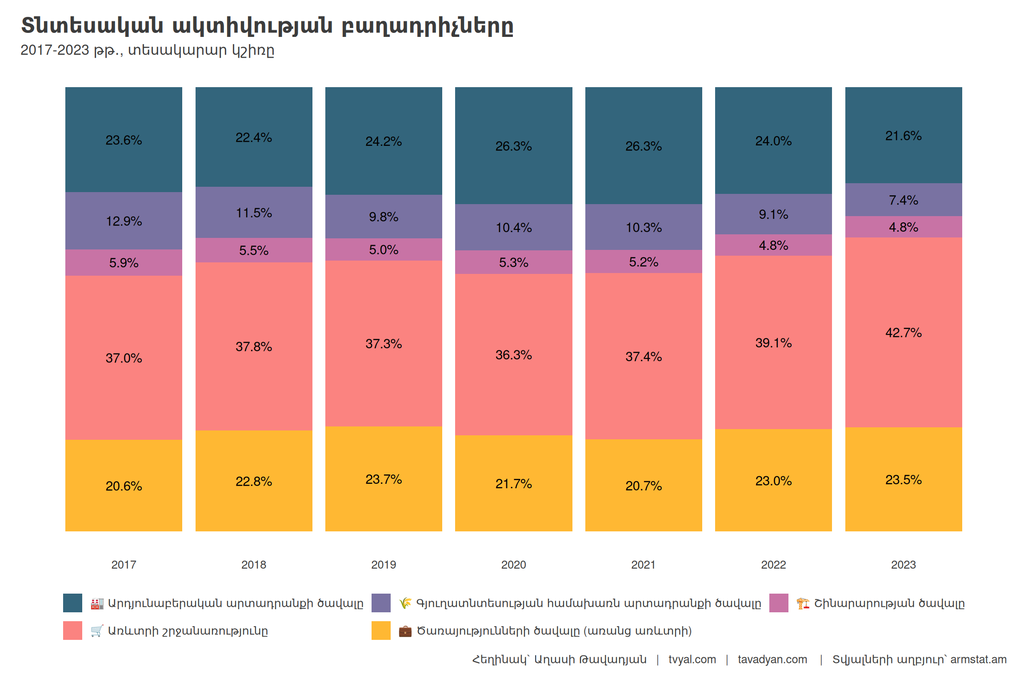

Չորրոդ գծապատկերը արտացոլում է տնտեսական բաղադրիչնեչը բացարձակ թվերով։

**Գծապատկեր 4.**

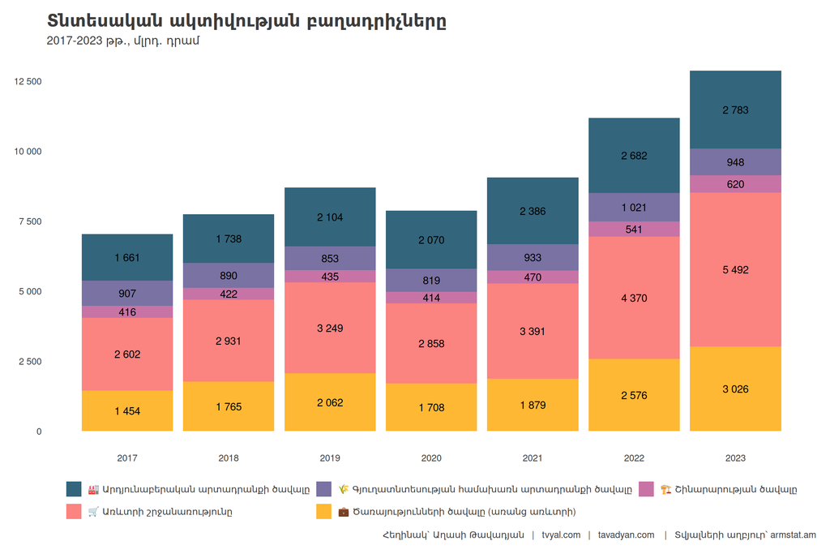

**Գծապատկեր 5.**

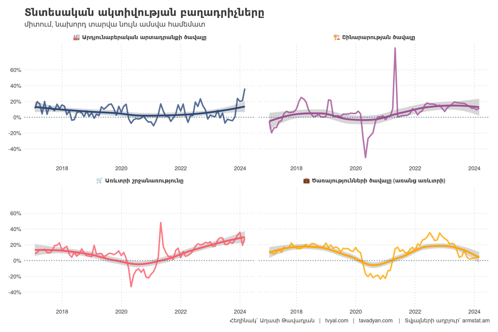

> Կարդացեք թե որ ճյուղերն են նպաստում տնտեսական աճին․

> [💸🔚🏦 Կապիտալի արտահոսք](https://www.tvyal.com/newsletter/2024/2024_03_01)։

## PODCAST !!

### Խոսենք թվերով #1

[Բենզինի գները Հայաստանում. Ինչպե՞ս է ձևավորվում, ինչպե՞ս կփոխվի](https://www.youtube.com/watch?v=TYcZsKjxzfY)

- 🔘 Ինչպե՞ս է Հայաստանում ձևավորվում բենզինի գինը,
- 🔘 Ի՞նչ գործոններից է կախված,
- 🔘 Թա՞նկ է, թե՞ էժան
- 🔘 Արդյո՞ք տնտեսվարողների միջև կա ներքին համաձայնություն
- 🔘 Ինչպե՞ս կփոխվի բենզինի գինը

How2B-ում «խոսում ենք թվերով»՝ տնտեսագետ Աղասի Թավադյանի հետ:

- 00:00 Ընդհանուր պատկերը
- 02:30 Որտե՞ղ է որոշվում բենզինի գինը
- 05:05 Բենզինի գների համեմատությունը Հայաստանում և հարևան երկրներում
- 08:38 Ի՞նչ է տալիս ԵԱՏՄ-ում լինելը Հայաստանին՝ բենզինի ներկրման հարցում
- 10:08 Ի՞նչ գործոններով է ձևավորվում բենզինի գինը Հայաստանում
- 14:40 Դրամ-դոլար փոխարժեքի ազդեցությունը բենզինի գնի վրա
- 18:13 Բենզինի գնի նվազեցումը՝ տնտեսական հարց է, թե քաղաքական
- 20:32 Մեր տնտեսության համար ավելի կարևոր է դիզելի գինը
- 23:30 Բենզինը կէժանանա՞, թե՞ կթանկանա

Թեմայով վերլուծությունը ներկայացված է tvyal.com կայքում՝ [⛽🚗🏷️Բենզինի գինը թա՞փ է հավաքում](https://www.tvyal.com/newsletter/2024/2024_03_22)

[figure not shown]

## ԶԼՄ հաղորդագրություն

[Դիտեք 1in.am-ին տված իմ վերջին հարցազրույցը, որտեղ խոսում եմ 2024 թվականի տնտեսական մարտահրավերների մասին։](https://youtu.be/wk07vyuAnnU?t=222)

📺 Հարցազրույցը արդեն դիտել է 10 000 մարդ 📺

Հարցազրույցում շոշափվել են հետևյալ թեմաները։

- 🎯 Ինչ հնարավոր վտանգներ տնտեսության համար, ինչը կարող է խաթարել պլանավորված 7 տոկոս տնտեսական աճը։
- 🎯 Ինչով է պայմանավորված վերաարտահանման աճը։ 25 տոկոս ոսկի և ադամանդներ արտահանման մե՞ջ։
- 🎯 Շինարարական բում Հայաստանում՝ կառավարությունը կրկնում է 2002-2007 թվականներին սխալները։
- 🎯 Ի՞նչ առավելություններ կտա Եվրոպական ուղին Հայաստանի տնտեսության համար։

[figure not shown]

## English Summary

### 🌿🤨💎 Expensive Effect: Unraveling the Economic Growth of 2024”

In February 2024, Armenia’s economic activity experienced a notable surge, with indicators showing a 16.3% growth compared to the previous year. This growth was primarily attributed to a sharp increase in jewelry activity, particularly in gold and diamond exports, which accounted for a significant portion of the country’s total exports. However, concerns arise regarding the sustainability of this growth, as it heavily relies on external factors and short-term stimuli, making the economy vulnerable to sudden changes in the global environment. Despite the positive impact on foreign currency inflows, the rapid expansion of jewelry activities has also led to a corresponding rise in imports, affecting the balance of trade and undermining the stability of traditional export sectors.

While the jewelry sector flourished, other key areas of the economy faced challenges. Sub-branches within the manufacturing industry, such as food, tobacco, clothing, and chemicals, experienced declines in January 2024. Additionally, both the construction and service sectors exhibited negative growth trends, contrasting with their earlier high growth rates in early 2023. Despite the growth observed in the industry and trade sectors, fueled mainly by re-exports of precious metals, the broader economic picture raises concerns about the structural integrity of Armenia’s economy, as short-term gains overshadow long-term stability and growth prospects.

Այս վերլուծությունը առկա է նաև [մեր կայքէջում](https://www.tvyal.com/newsletter/2024/2024_03_29), այս վերլուծության կոդը և տվյալները դրված են նաև [Github-ում](https://github.com/tavad/tvyal_newsletter)։

Եթե հնարավոր է, խնդրում եմ այս նյութը ուղարկել նաև այն մարդկանց, ում այն կարծում եք կարող է հետաքրքրել:

Սպասեք հաջորդ հաղորդագրությանը հաջորդ ուրբաթ օրը:

Հարգանքներով,  
Աղասի Թավադյան  
29.03.2024  
[tvyal.com](https://www.tvyal.com/)  
[tavadyan.com](https://www.tavadyan.com/)

[Was this email forwarded to you? Subscribe here.](https://www.tvyal.com/subscribe)

[Բաժանորդագրվեք](https://www.tvyal.com/subscribe)

**Ուշադրություն. Ձեր էլ.փոստը մեյլիսթի մեջ է, որի միջոցով ես կիսվում եմ շաբաթական նյութեր, որոնք հիմնականում ներկայացնում են Հայաստանի տնտեսությանը: Նյութերը ներառում են գծապատկերներ, [տվյալների բազաներ](https://github.com/tavad/tvyal_newsletter), տեսանյութեր, հոդվածներ, [առցանց վահանակներ](https://www.tvyal.com/projects), տնտեսական գործիքներ, կանխատեսումներ և հաշվետվություններ: Եթե ցանկանում եք չեղարկել բաժանորդագրությունը, խնդրում եմ տեղեկացրեք ինձ, և ես կհեռացնեմ ձեր էլ. փոստը ցուցակից: Գրեք նաև եթե ունեք մենկնաբանություններ:**

**Important! Your email is part of the mailing list where I share weekly materials primarily focused on the Armenian economy. These materials encompass charts, [databases](https://github.com/tavad/tvyal_newsletter), videos, articles, [online dashboards](https://www.tvyal.com/projects), economic tools, forecasts, and reports. If you wish to unsubscribe, please let me know, and I will remove your email from the list. Please share your comments as well․**